# Tract-Level Analysis: Housing Growth, Demographic Change, and Greenness Exposure

Lilac Hong

2026-04-30

## Guiding questions

1. **Where is housing being built and who lives there** (and how have demographics changed over time)?
2. **Who is experiencing changes in exposure to green environments?**

## Demographic categories

- **Race:** AIAN, Asian, Black, NHOPI, Two or More, White
- **Age:** 0–19, 20–29, 30–59, 60+

## Part I: Pseudo-Residual Greenness Analysis

$\text{NDVI}_{2010} = \alpha + \beta \cdot \log(\text{HU_density}_{2010})$

- GHI<sub>2010</sub> = NDVI<sub>2010</sub> − ($\hat{\alpha}_{2010}$ + $\hat{\beta}_{2010}$ · log(HU_density<sub>2010</sub>))
- GHI<sub>2020</sub> = NDVI<sub>2020</sub> − ($\hat{\alpha}_{2010}$ + $\hat{\beta}_{2010}$ · log(HU_density<sub>2020</sub>))
- **ΔGHI = GHI<sub>2020</sub> − GHI<sub>2010</sub>**

Sample: **1318** unique tracts.

### Table 1 — 2010 baseline regressions

| season | buffer | intercept | slope | slope_se | slope_p | R2 | n |
| --- | --- | --- | --- | --- | --- | --- | --- |
| Dormant_Season | 1000 | 0.5458 | -0.0436 | 0.0014 | 0 | 0.4248 | 1318 |
| Growing_Season | 1000 | 0.6384 | -0.0491 | 0.0013 | 0 | 0.5092 | 1318 |

At the tract scale, the housing-density–NDVI relationship is strongly negative (slope ≈ −0.044 to −0.049), with R² of 0.42–0.51. This reveals the expected urban signal: denser tracts are measurably less green.

### Table 2 — ΔGHI summary

| season | buffer | n | mean | sd | median | pct_bright | pct_dim |
| --- | --- | --- | --- | --- | --- | --- | --- |
| Dormant_Season | 1000 | 1318 | -0.0862 | 0.0992 | -0.0694 | 19.8786 | 80.1214 |
| Growing_Season | 1000 | 1318 | 0.0106 | 0.0189 | 0.0114 | 77.7693 | 22.2307 |

The two seasons tell fundamentally different stories. In the dormant season, the average tract dimmed by 0.086 NDVI units, and 80% of tracts dimmed — indicating widespread loss of structural and evergreen vegetation visible during leaf-off conditions. In the growing season, the pattern reverses: the average tract brightened slightly (+0.011), and 78% of tracts brightened, suggesting that active-season canopy held or improved even as winter greenness declined. A tract can simultaneously lose dormant-season greenness and gain growing-season greenness; this is not a contradiction but reflects different ecological signals (evergreen/structural cover vs. deciduous canopy cover).

### Table 3 — Bright/Dim transitions

| season | buffer | Bright -> Bright | Bright -> Dim | Dim -> Bright | Dim -> Dim |
| --- | --- | --- | --- | --- | --- |
| Dormant_Season | 1000 | 232 | 495 | 57 | 534 |
| Growing_Season | 1000 | 759 | 22 | 69 | 468 |

The dormant-season transition asymmetry is striking: 495 tracts shifted from Bright to Dim, while only 57 moved from Dim to Bright — an 8.7:1 ratio. This is sharper than the block-level asymmetry (7.5:1). In the growing season, Bright→Bright dominates (759 tracts), and the few transitions that occur slightly favor improvement (69 Dim→Bright vs. 22 Bright→Dim).

### Greenness figures

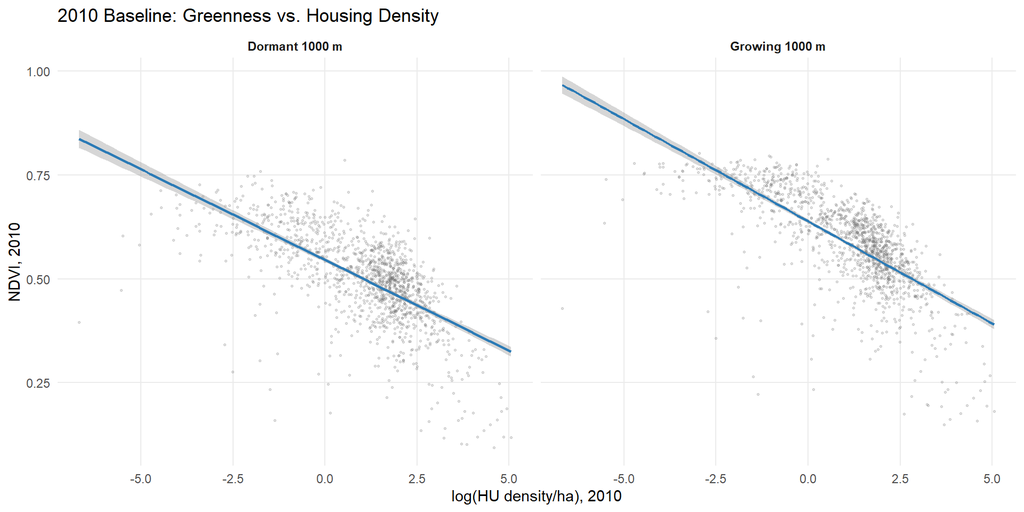

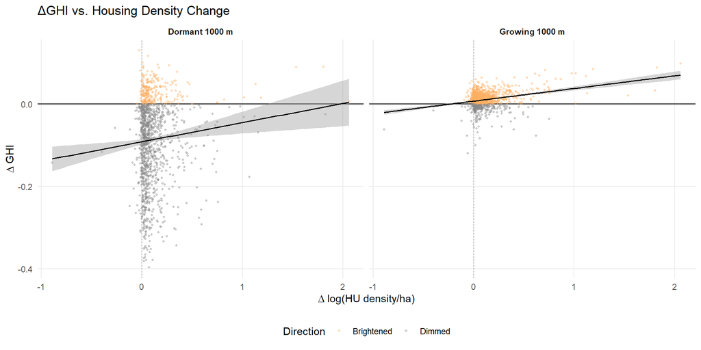

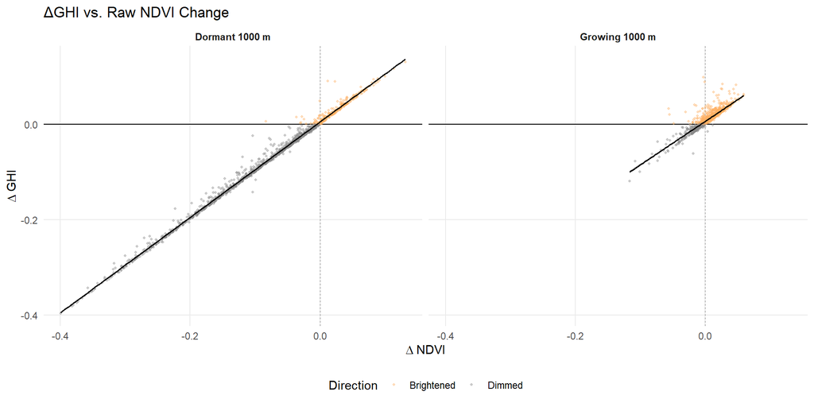

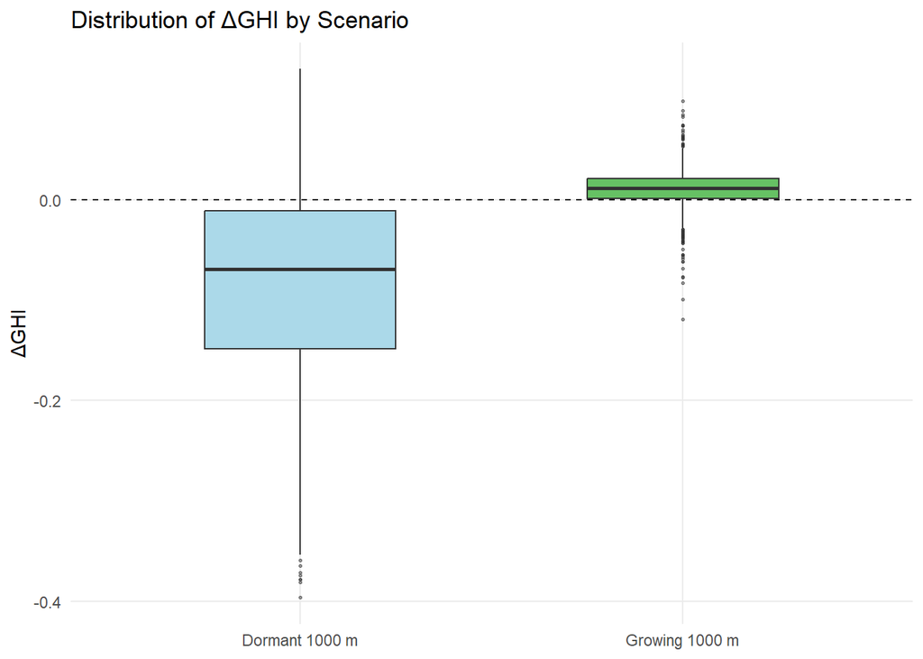

## Part II: Where Is Housing Being Built and Who Lives There?

### Table 4 — Housing growth summary

|  | Value |
| --- | --- |
| n_tracts | 1318.0 |
| total_HU_2010 | 2196124.9 |
| total_HU_2020 | 2451417.0 |
| total_delta_HU | 255292.1 |
| pct_gained | 91.8 |
| pct_lost | 8.2 |
| median_delta_HU | 101.7 |
| mean_delta_HU | 193.7 |
| total_POP_2010 | 5102530.9 |
| total_POP_2020 | 5902734.1 |
| total_delta_POP | 800203.2 |

Washington’s 1,318 analytical tracts gained approximately 255,000 housing units between 2010 and 2020, a net increase of 11.6%. Housing growth was nearly universal: 92% of tracts gained units, while only 8% lost them. However, growth was highly concentrated — the mean gain (194 units) was nearly double the median (102 units), indicating a right-skewed distribution in which a minority of tracts absorbed a disproportionate share of new construction. Population grew by approximately 800,000 over the same period.

### Table 5a — Race composition by housing growth quartile

| hu_growth_q | n | mean_dHU | mean_delta_pct_AIAN | mean_delta_pct_Asian | mean_delta_pct_Black | mean_delta_pct_NHOPI | mean_delta_pct_Two_or_More | mean_delta_pct_White |
| --- | --- | --- | --- | --- | --- | --- | --- | --- |
| Q1 (least) | 330 | -0.3 | 0.1 | 2.0 | 0.4 | 0.2 | 5.7 | -8.5 |
| Q2 | 329 | 66.3 | 0.1 | 1.7 | 0.4 | 0.2 | 5.5 | -7.8 |
| Q3 | 329 | 160.6 | 0.2 | 2.2 | 0.6 | 0.3 | 5.5 | -8.7 |
| Q4 (most) | 330 | 547.7 | 0.0 | 4.6 | 0.5 | 0.3 | 5.5 | -11.0 |

### Table 5b — Age composition by housing growth quartile

| hu_growth_q | n | mean_dHU | mean_delta_pct_0_19 | mean_delta_pct_20_29 | mean_delta_pct_30_59 | mean_delta_pct_60p |
| --- | --- | --- | --- | --- | --- | --- |
| Q1 (least) | 330 | -0.3 | -2.0 | 0.4 | -3.4 | 5.0 |
| Q2 | 329 | 66.3 | -2.1 | 0.3 | -3.7 | 5.4 |
| Q3 | 329 | 160.6 | -2.4 | 0.6 | -3.2 | 5.0 |
| Q4 (most) | 330 | 547.7 | -2.0 | 2.0 | -2.7 | 2.8 |

### Figure — Race composition by housing growth quartile

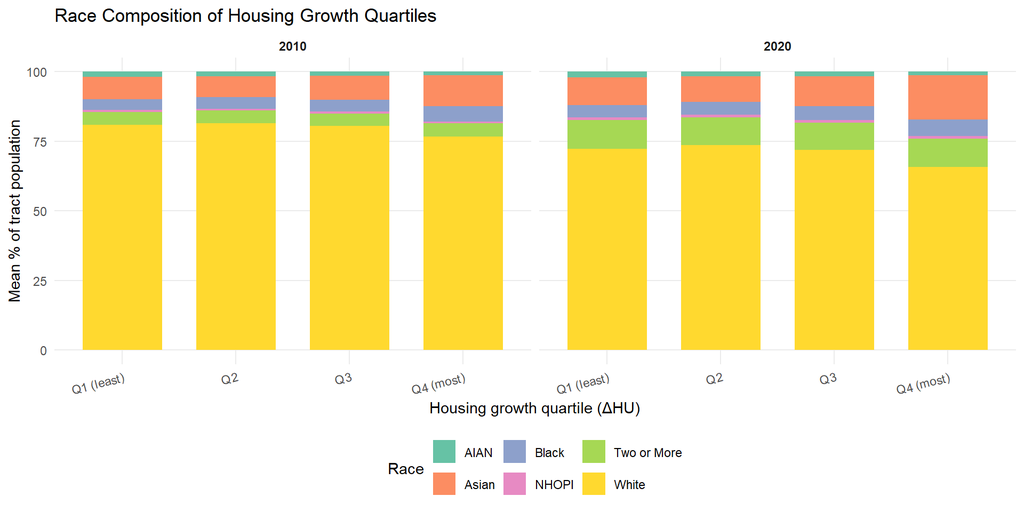

### Figure — Age composition by housing growth quartile

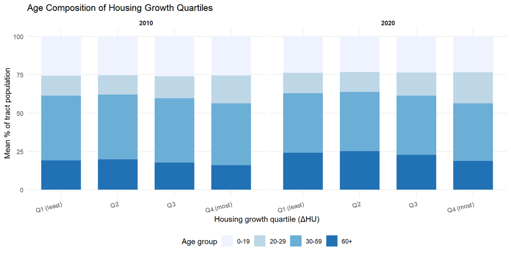

### Table 6 — Correlations: housing growth × demographics

| variable | r_dHU |
| --- | --- |
| pct_AIAN_2010 | -0.063 |
| pct_Asian_2010 | 0.172 |
| pct_Black_2010 | 0.071 |
| pct_NHOPI_2010 | -0.051 |
| pct_Two_or_More_2010 | 0.000 |
| pct_White_2010 | -0.122 |
| pct_AIAN_2020 | -0.085 |
| pct_Asian_2020 | 0.284 |
| pct_Black_2020 | 0.054 |
| pct_NHOPI_2020 | -0.053 |
| pct_Two_or_More_2020 | -0.065 |
| pct_White_2020 | -0.193 |
| delta_pct_AIAN | -0.073 |
| delta_pct_Asian | 0.361 |
| delta_pct_Black | -0.046 |
| delta_pct_NHOPI | -0.034 |
| delta_pct_Two_or_More | -0.090 |
| delta_pct_White | -0.242 |
| pct_0_19_2010 | -0.066 |
| pct_20_29_2010 | 0.397 |
| pct_30_59_2010 | -0.139 |
| pct_60p_2010 | -0.157 |
| pct_0_19_2020 | -0.054 |
| pct_20_29_2020 | 0.481 |
| pct_30_59_2020 | -0.128 |
| pct_60p_2020 | -0.273 |
| delta_pct_0_19 | 0.042 |
| delta_pct_20_29 | 0.376 |
| delta_pct_30_59 | 0.043 |
| delta_pct_60p | -0.364 |

The correlation table confirms the quartile patterns. The strongest demographic predictor of housing growth is the 20–29 age share (r = 0.40 in 2010, r = 0.48 in 2020), followed by the change in 20–29 share (r = 0.38) and the change in Asian share (r = 0.36). Housing growth is negatively correlated with the 60+ share (r = −0.27 in 2020) and with the change in 60+ share (r = −0.36).

## Part III: Who Is Experiencing Changes in Exposure to Green Environments?

We stratify greenness outcomes by the demographic composition of the tract to answer: are particular populations disproportionately exposed to greenness loss? We use 2020 demographics (who lives there when the change is realized) as the primary stratifier and use White as an example to test.

### Table 7 — ΔGHI by % White tercile (2020)

| scenario | white_tercile_2020 | n | mean_DGHI | sd | median | pct_bright | mean_pct_White | mean_NDVI_2010 | mean_NDVI_2020 | mean_dNDVI |
| --- | --- | --- | --- | --- | --- | --- | --- | --- | --- | --- |
| Dormant 1000 m | Low White | 440 | -0.086 | 0.093 | -0.069 | 16.136 | 52.460 | 0.450 | 0.358 | -0.092 |
| Dormant 1000 m | Mid White | 439 | -0.092 | 0.101 | -0.078 | 18.907 | 73.958 | 0.484 | 0.386 | -0.097 |
| Dormant 1000 m | High White | 439 | -0.081 | 0.103 | -0.060 | 24.601 | 86.329 | 0.569 | 0.485 | -0.084 |
| Growing 1000 m | Low White | 440 | 0.011 | 0.020 | 0.010 | 76.364 | 52.460 | 0.534 | 0.537 | 0.003 |
| Growing 1000 m | Mid White | 439 | 0.012 | 0.017 | 0.012 | 76.538 | 73.958 | 0.566 | 0.572 | 0.006 |
| Growing 1000 m | High White | 439 | 0.009 | 0.019 | 0.011 | 80.410 | 86.329 | 0.664 | 0.669 | 0.005 |

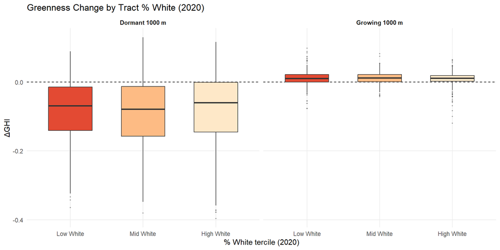

### Table 9 — Bright/Dim transitions by % White tercile

| scenario | white_tercile_2020 | transition_green | n | pct |
| --- | --- | --- | --- | --- |
| Dormant 1000 m | Low White | Bright -> Bright | 69 | 15.7 |
| Dormant 1000 m | Low White | Bright -> Dim | 155 | 35.2 |
| Dormant 1000 m | Low White | Dim -> Bright | 13 | 3.0 |
| Dormant 1000 m | Low White | Dim -> Dim | 203 | 46.1 |
| Dormant 1000 m | Mid White | Bright -> Bright | 75 | 17.1 |
| Dormant 1000 m | Mid White | Bright -> Dim | 181 | 41.2 |
| Dormant 1000 m | Mid White | Dim -> Bright | 20 | 4.6 |
| Dormant 1000 m | Mid White | Dim -> Dim | 163 | 37.1 |
| Dormant 1000 m | High White | Bright -> Bright | 88 | 20.0 |
| Dormant 1000 m | High White | Bright -> Dim | 159 | 36.2 |
| Dormant 1000 m | High White | Dim -> Bright | 24 | 5.5 |
| Dormant 1000 m | High White | Dim -> Dim | 168 | 38.3 |
| Growing 1000 m | Low White | Bright -> Bright | 236 | 53.6 |
| Growing 1000 m | Low White | Bright -> Dim | 9 | 2.0 |
| Growing 1000 m | Low White | Dim -> Bright | 12 | 2.7 |
| Growing 1000 m | Low White | Dim -> Dim | 183 | 41.6 |
| Growing 1000 m | Mid White | Bright -> Bright | 260 | 59.2 |
| Growing 1000 m | Mid White | Bright -> Dim | 5 | 1.1 |
| Growing 1000 m | Mid White | Dim -> Bright | 30 | 6.8 |
| Growing 1000 m | Mid White | Dim -> Dim | 144 | 32.8 |
| Growing 1000 m | High White | Bright -> Bright | 263 | 59.9 |
| Growing 1000 m | High White | Bright -> Dim | 8 | 1.8 |
| Growing 1000 m | High White | Dim -> Bright | 27 | 6.2 |
| Growing 1000 m | High White | Dim -> Dim | 141 | 32.1 |

### Table 10 — NDVI levels and housing by % White tercile

| scenario | white_tercile_2020 | n | mean_NDVI_2010 | mean_NDVI_2020 | mean_dNDVI | mean_HU_dens_2010 | mean_HU_dens_2020 | mean_dHU |
| --- | --- | --- | --- | --- | --- | --- | --- | --- |
| Dormant 1000 m | Low White | 440 | 0.450 | 0.358 | -0.092 | 11.123 | 14.279 | 262.978 |
| Dormant 1000 m | Mid White | 439 | 0.484 | 0.386 | -0.097 | 8.336 | 9.524 | 185.297 |
| Dormant 1000 m | High White | 439 | 0.569 | 0.485 | -0.084 | 2.222 | 2.396 | 132.657 |
| Growing 1000 m | Low White | 440 | 0.534 | 0.537 | 0.003 | 11.123 | 14.279 | 262.978 |
| Growing 1000 m | Mid White | 439 | 0.566 | 0.572 | 0.006 | 8.336 | 9.524 | 185.297 |
| Growing 1000 m | High White | 439 | 0.664 | 0.669 | 0.005 | 2.222 | 2.396 | 132.657 |

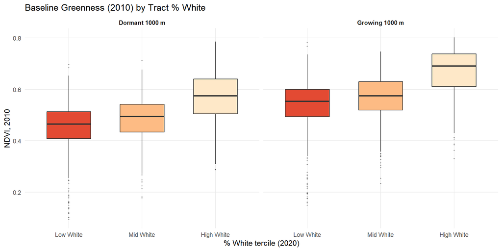

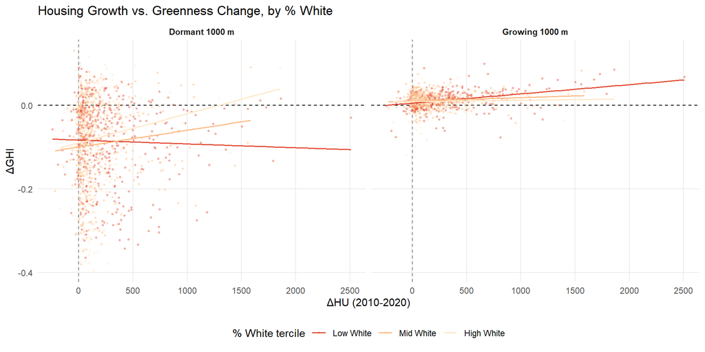

### Table 11 — ΔGHI correlations with all demographic variables

| variable | Dormant 1000 m | Growing 1000 m |
| --- | --- | --- |
| cor_dGHI_pct_AIAN_2020 | 0.101 | -0.072 |
| cor_dGHI_pct_Asian_2020 | -0.124 | 0.185 |
| cor_dGHI_pct_Black_2020 | 0.105 | -0.111 |
| cor_dGHI_pct_NHOPI_2020 | 0.271 | -0.220 |
| cor_dGHI_pct_Two_or_More_2020 | 0.176 | -0.135 |
| cor_dGHI_pct_White_2020 | -0.026 | -0.035 |
| cor_dGHI_delta_pct_AIAN | 0.101 | -0.088 |
| cor_dGHI_delta_pct_Asian | -0.070 | 0.248 |
| cor_dGHI_delta_pct_Black | 0.016 | -0.096 |
| cor_dGHI_delta_pct_NHOPI | 0.194 | -0.143 |
| cor_dGHI_delta_pct_Two_or_More | 0.097 | -0.131 |
| cor_dGHI_delta_pct_White | -0.025 | -0.092 |
| cor_dGHI_pct_0_19_2020 | 0.088 | 0.028 |
| cor_dGHI_pct_20_29_2020 | 0.064 | 0.164 |
| cor_dGHI_pct_30_59_2020 | -0.080 | 0.041 |
| cor_dGHI_pct_60p_2020 | -0.069 | -0.181 |
| cor_dGHI_delta_pct_0_19 | -0.081 | 0.101 |
| cor_dGHI_delta_pct_20_29 | 0.047 | 0.102 |
| cor_dGHI_delta_pct_30_59 | 0.063 | 0.055 |
| cor_dGHI_delta_pct_60p | -0.038 | -0.197 |
| cor_dGHI_dHU | 0.044 | 0.214 |
| cor_dGHI_dPOP | 0.035 | 0.156 |

### Table 12 — Demographic summary (all WA tracts)

|  | Value |
| --- | --- |
| n_tracts | 1784.00 |
| mean_pct_AIAN_2010 | 1.99 |
| mean_pct_Asian_2010 | 7.04 |
| mean_pct_Black_2010 | 3.63 |
| mean_pct_NHOPI_2010 | 0.61 |
| mean_pct_Two_or_More_2010 | 4.10 |
| mean_pct_White_2010 | 82.63 |
| mean_pct_AIAN_2020 | 2.14 |
| mean_pct_Asian_2020 | 9.05 |
| mean_pct_Black_2020 | 4.03 |
| mean_pct_NHOPI_2020 | 0.85 |
| mean_pct_Two_or_More_2020 | 10.06 |
| mean_pct_White_2020 | 73.87 |
| mean_pct_0_19_2010 | 26.42 |
| mean_pct_0_19_2020 | 24.24 |
| mean_pct_20_29_2010 | 13.98 |
| mean_pct_20_29_2020 | 14.68 |
| mean_pct_30_59_2010 | 41.06 |
| mean_pct_30_59_2020 | 37.84 |
| mean_pct_60p_2010 | 18.54 |
| mean_pct_60p_2020 | 23.24 |

### Race composition (2020) vs. greenness change

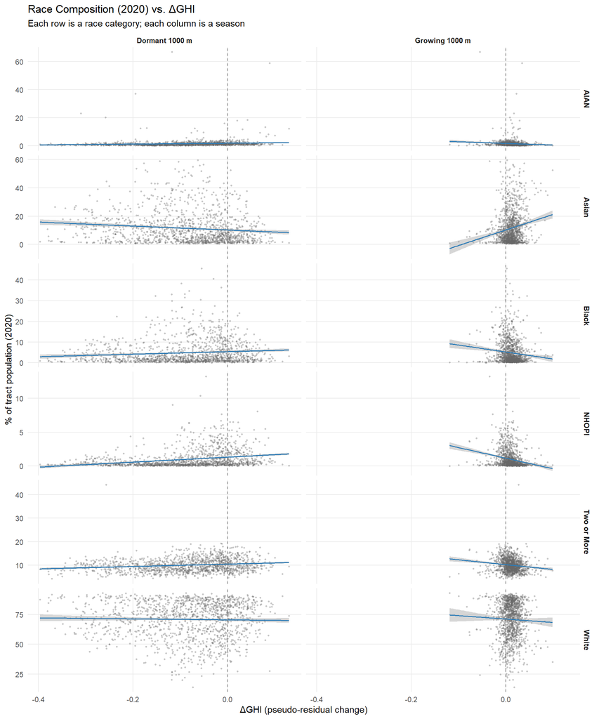

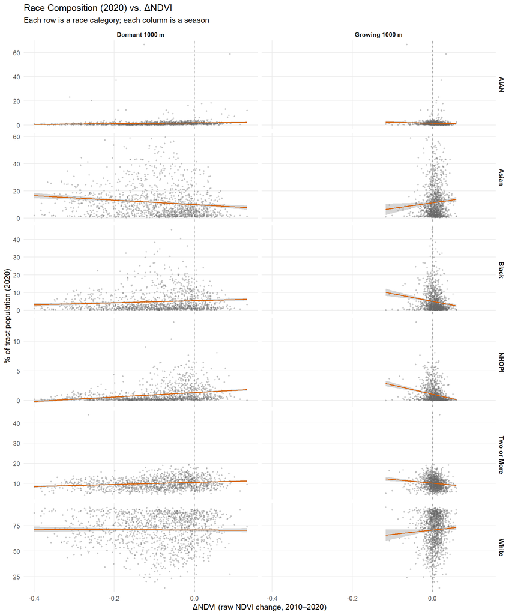

### Age composition (2020) vs. greenness change

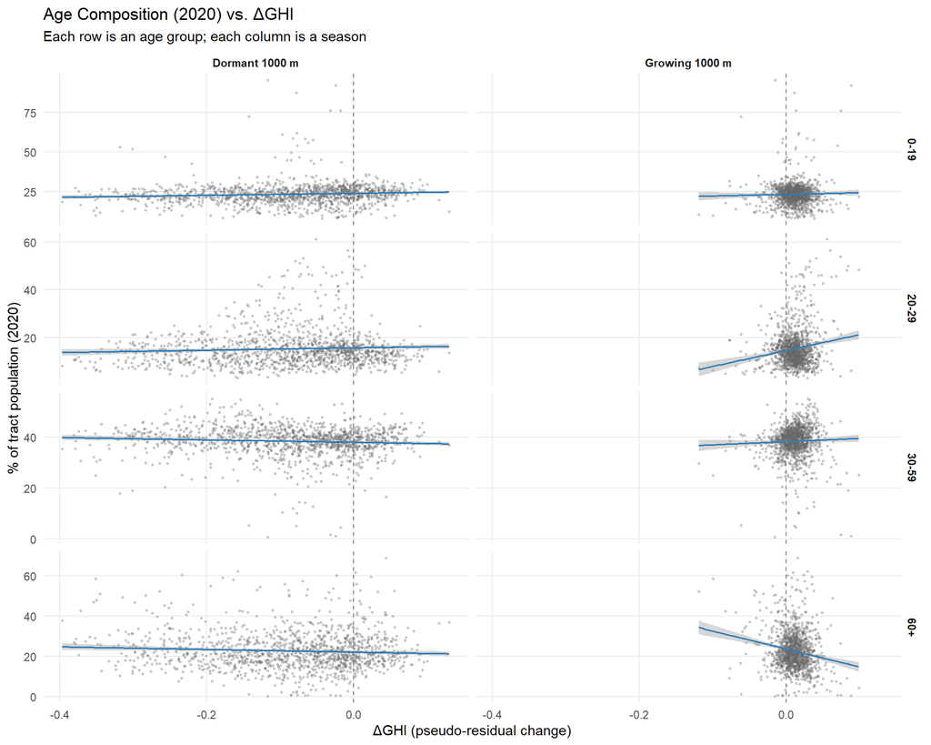

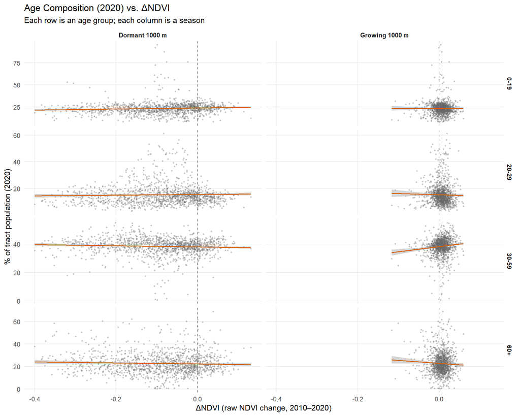

### Change in race composition vs. greenness change

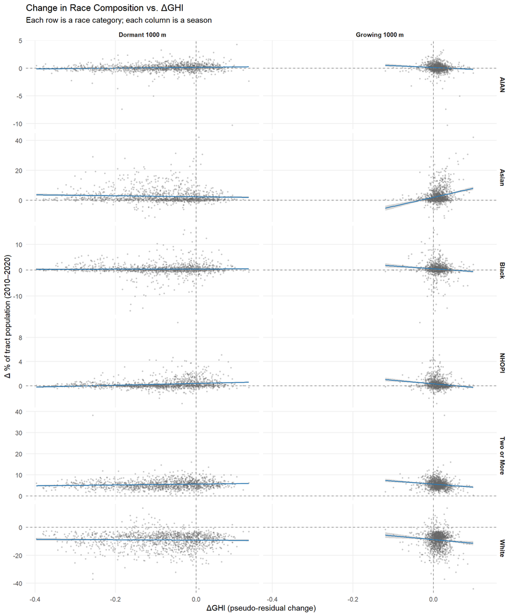

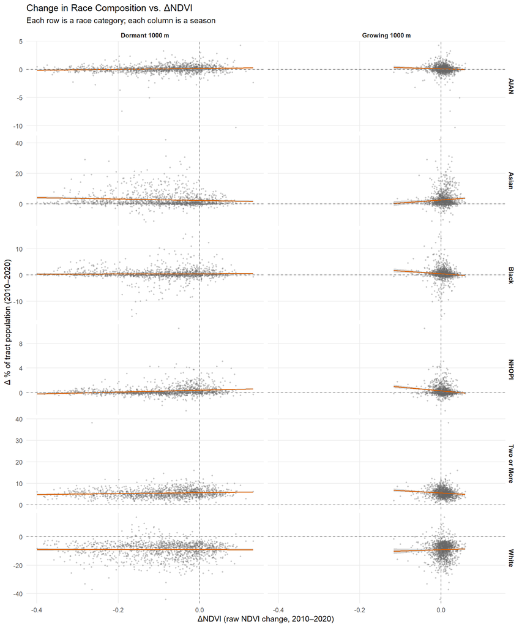

### Change in age composition vs. greenness change

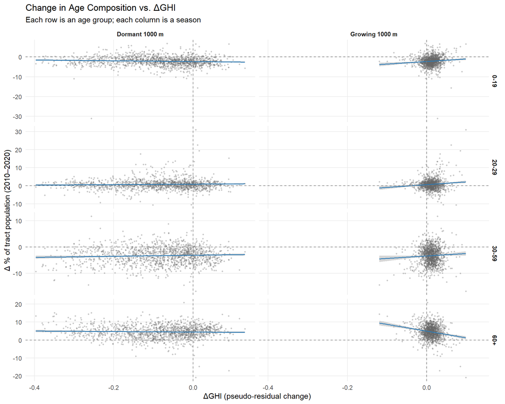

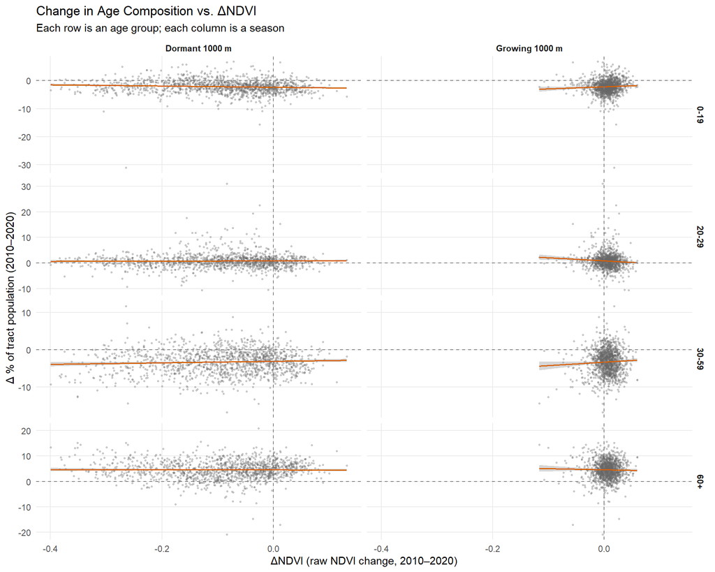

## Reference

Lambert, M. R., Des Roches, S., Auerbach, D. A., Van Deynze, B., Behrens, S., Hale, R., & Pierce, K. B. (2025). Building the neighborhood for the trees: Illuminating win–wins for housing densification and nature. *Conservation Science and Practice*, 7(7), e70085.